# Feature Selection: Practical 1

Effect of Irrelevant Features on Model Performance

Solon Karapanagiotis

21-04-2026

© 2026 Solon Karapanagiotis. All rights reserved.

# 1 Overview

This document runs a simulation study comparing several machine learning models when the dataset contains an increasing number of (irrelevant) features.

The file generates synthetic data where:

- Only 20 features truly affect the outcome.
- Up to 100 irrelevant features are added.
- Several machine learning models are compared using root mean squared error (RMSE) on a test set.

We vary:

Models compared:

1. Understand the simulation
2. Analyse the results
3. Extend the experiment
4. Interpret the findings

# 2 Load Libraries and Set Seed

```r
library(glmnet)        # LASSO regression
library(caret)         # modelling framework
library(randomForest)  # Random Forest
library(e1071)         # SVM
library(dplyr)
library(ggplot2)

set.seed(123)  # reproducibility
```

# 3 Simulation Design

We create a controlled experiment:

- Only 20 features truly matter.
- Up to 100 irrelevant predictors are added.

We repeat experiments 10 times for stability.

```r
n_train_sizes <- c(500, 1000)
num_relevant <- 20
num_irrelevant <- seq(from = 0, to = 100, by = 20)
sigma_error <- 3
n_test <- 10000
num_sim <- 10
```

# 4 True Data Generating Function

$$\begin{align}
f(X) = {} & X_1 + \sin(X_2) + \log\left(|X_3| + 10^{-8}\right) +
X_4^2 + X_5 X_6 \nonumber \\
& + \mathbb{1}(X_7 X_8 X_9 < 0) + \mathbb{1}(X_{10} > 0) +
X_{11}\,\mathbb{1}(X_{11} > 0) \nonumber \\
& + \sqrt{|X_{12}|} + \cos(X_{13}) + 2X_{14} + |X_{15}| \nonumber \\
& + \mathbb{1}(X_{16} < -1) + X_{17}\,\mathbb{1}(X_{17} < -1)
- 2X_{18} - X_{19}X_{20}.
\end{align}$$

$$y = f(X) + \epsilon$$

where $\epsilon \sim N(0, 3)$.

```r
f_relevant <- function(X) {
    X <- as.data.frame(X)
    X1 <- X[,1]; X2 <- X[,2]; X3 <- X[,3]; X4 <- X[,4]; X5 <- X[,5]
    X6 <- X[,6]; X7 <- X[,7]; X8 <- X[,8]; X9 <- X[,9]; X10 <- X[,10]
    X11 <- X[,11]; X12 <- X[,12]; X13 <- X[,13]; X14 <- X[,14]; X15 <- X[,15]
    X16 <- X[,16]; X17 <- X[,17]; X18 <- X[,18]; X19 <- X[,19]; X20 <- X[,20]

    X1 + sin(X2) + log(abs(X3) + 1e-8) + X4^2 + X5*X6 +
        as.numeric(X7*X8*X9 < 0) + as.numeric(X10 > 0) +
        X11 * as.numeric(X11 > 0) + sqrt(abs(X12)) + cos(X13) +
        2*X14 + abs(X15) + as.numeric(X16 < -1) +
        X17 * as.numeric(X17 < -1) - 2*X18 - X19*X20
}
```

# 5 Create Results Grid

Each row represents one experiment configuration.

```r
results <- expand.grid(
    n_train = n_train_sizes,
    n_irrelevant = num_irrelevant,
    model = c("Linear", "Lasso", "RF")
) %>%
    mutate(RMSE = NA)
```

# 6 Main Simulation Loop

For each configuration we:

1. Generate training data
2. Generate test data
3. Fit model
4. Compute RMSE
5. Repeat and average

**DO NOT RUN**

```r
for(i in 1:nrow(results)) {

    n_train <- results$n_train[i]
    p_irrelevant <- results$n_irrelevant[i]
    model_type <- results$model[i]

    rmse_sim <- numeric(num_sim)

    for(sim in 1:num_sim) {

        # Generate training data
        X_relevant <- matrix(rnorm(n_train * num_relevant), n_train, num_relevant)
        colnames(X_relevant) <- paste0("X", 1:num_relevant)

        if(p_irrelevant > 0) {
            X_irrelevant <- matrix(rnorm(n_train * p_irrelevant), n_train, p_irrelevant)
            colnames(X_irrelevant) <- paste0("Z", 1:p_irrelevant)
        } else {
            X_irrelevant <- matrix(nrow = n_train, ncol = 0)
        }

        X_train <- cbind(X_relevant, X_irrelevant)
        y_train <- f_relevant(X_relevant) + rnorm(n_train, 0, sigma_error)

        df_train <- as.data.frame(X_train)
        df_train$y <- y_train

        # Generate test data
        X_relevant_test <- matrix(rnorm(n_test * num_relevant), n_test, num_relevant)
        colnames(X_relevant_test) <- paste0("X", 1:num_relevant)

        if(p_irrelevant > 0) {
            X_irrelevant_test <- matrix(rnorm(n_test * p_irrelevant), n_test, p_irrelevant)
            colnames(X_irrelevant_test) <- paste0("Z", 1:p_irrelevant)
        } else {
            X_irrelevant_test <- matrix(nrow = n_test, ncol = 0)
        }

        X_test <- cbind(X_relevant_test, X_irrelevant_test)
        y_test <- f_relevant(X_relevant_test) + rnorm(n_test, 0, sigma_error)
        df_test <- as.data.frame(X_test)

        # Fit models
        if(model_type == "Linear") {
            fit <- lm(y ~ ., data = df_train)
            y_pred <- predict(fit, newdata = df_test)

        } else if(model_type == "Lasso") {
            fit <- cv.glmnet(as.matrix(df_train[,-ncol(df_train)]), df_train$y, alpha = 1)
            y_pred <- predict(fit, s = "lambda.min", newx = as.matrix(df_test))

        } else if(model_type == "RF") {
            fit <- randomForest(y ~ ., data = df_train, ntree = 200)
            y_pred <- predict(fit, newdata = df_test)

        } else if(model_type == "SVM") {
            fit <- svm(y ~ ., data = df_train, kernel = "radial")
            y_pred <- predict(fit, newdata = df_test)
        }

        rmse_sim[sim] <- sqrt(mean((y_test - y_pred)^2))
    }

    results$RMSE[i] <- mean(rmse_sim)
    cat("Done:", i, "/", nrow(results), "\n")
}
```

Notes

- Runtime ≈ 15 minutes depending on hardware.
- Increase num_sim for more accurate estimates.

## 6.1 Parallel Simulation

```r
library(doParallel)
library(foreach)

# Detect cores and create cluster
if (interactive()) {
  n_cores <- parallel::detectCores() - 1
} else {
  n_cores <- 2
}

cl <- parallel::makeCluster(n_cores)
doParallel::registerDoParallel(cl)

cat("Using", n_cores, "cores\n")
```

```
## Using 2 cores
```

```r
# ------------------------------
# Experiment grid
# ------------------------------
grid <- expand.grid(
    n_train = n_train_sizes,
    n_irrelevant = num_irrelevant,
    model = c("Linear", "Lasso", "RF", "SVM")
)
```

```r
results <- foreach(i = 1:nrow(grid),
                   .combine = rbind,
                   .packages = c("glmnet","randomForest","e1071","caret","dplyr")) %dopar% {

    n_train <- grid$n_train[i]
    p_irrelevant <- grid$n_irrelevant[i]
    model_type <- grid$model[i]

    rmse_sim <- numeric(num_sim)

    for(sim in 1:num_sim) {

        # ---- Training data ----
        X_relevant <- matrix(rnorm(n_train * num_relevant), n_train, num_relevant)
        colnames(X_relevant) <- paste0("X", 1:num_relevant)

        if(p_irrelevant > 0){
            X_irrelevant <- matrix(rnorm(n_train * p_irrelevant), n_train, p_irrelevant)
            colnames(X_irrelevant) <- paste0("Z", 1:p_irrelevant)
        } else {
            X_irrelevant <- matrix(nrow=n_train,ncol = 0)
        }

        X_train <- cbind(X_relevant, X_irrelevant)
        y_train <- f_relevant(X_relevant) + rnorm(n_train, 0, sigma_error)

        df_train <- as.data.frame(X_train)
        df_train$y <- y_train

        # ---- Test data ----
        X_relevant_test <- matrix(rnorm(n_test * num_relevant), n_test, num_relevant)
        colnames(X_relevant_test) <- paste0("X", 1:num_relevant)

        if(p_irrelevant > 0){
            X_irrelevant_test <- matrix(rnorm(n_test * p_irrelevant), n_test, p_irrelevant)
            colnames(X_irrelevant_test) <- paste0("Z", 1:p_irrelevant)
        } else {
            X_irrelevant_test <- matrix(nrow=n_test,ncol = 0)
        }

        X_test <- cbind(X_relevant_test, X_irrelevant_test)
        y_test <- f_relevant(X_relevant_test) + rnorm(n_test, 0, sigma_error)
        df_test <- as.data.frame(X_test)

        # ---- Fit model ----
        if(model_type == "Linear"){
            fit <- lm(y~., data=df_train)
            y_pred <- predict(fit, df_test)

        } else if(model_type == "Lasso"){
            fit <- cv.glmnet(as.matrix(df_train[,-ncol(df_train)]), df_train$y, alpha=1)
            y_pred <- predict(fit, s = "lambda.min", newx=as.matrix(df_test))

        } else if(model_type == "RF"){
            fit <- randomForest(y~., data=df_train, ntree = 200)
            y_pred <- predict(fit, df_test)

        } else if(model_type == "SVM"){
            fit <- svm(y~., data = df_train, kernel = "radial")
            y_pred <- predict(fit, df_test)
        }

        rmse_sim[sim] <- sqrt(mean((y_test - y_pred)^2))
    }

    data.frame(
        n_train = n_train,
        n_irrelevant = p_irrelevant,
        model = model_type,
        RMSE = mean(rmse_sim)
    )
}

# ------------------------------
# Stop cluster
# ------------------------------
stopCluster(cl)

cat("Simulation complete!\n")
```

```r
head(results)
```

|  | n_train | n_irrelevant | model | RMSE |
| --- | --- | --- | --- | --- |
| 1 | 500 | 0 | Linear | 4.029327 |
| 2 | 1000 | 0 | Linear | 4.003525 |
| 3 | 500 | 20 | Linear | 4.172212 |
| 4 | 1000 | 20 | Linear | 4.037234 |
| 5 | 500 | 40 | Linear | 4.215877 |
| 6 | 1000 | 40 | Linear | 4.089896 |

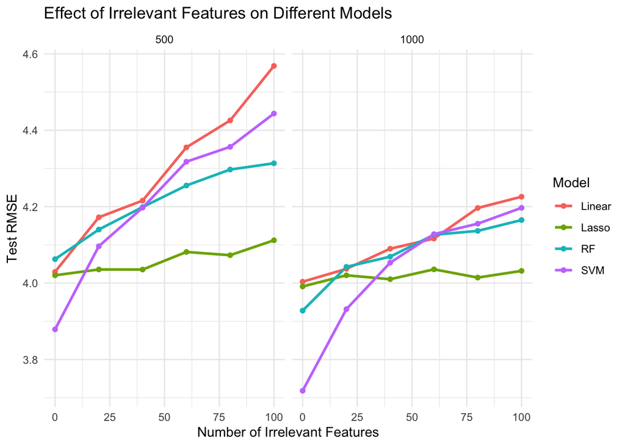

```r
ggplot(results, aes(x = n_irrelevant, y = RMSE, color = model)) +
    geom_line(linewidth = 1) +
    geom_point() +
    facet_wrap(~ n_train) +
    labs(
        x = "Number of Irrelevant Features",
        y = "Test RMSE",
        color = "Model",
        title = "Effect of Irrelevant Features on Different Models"
    ) +
    theme_minimal()
```

# 7 Practical

## 7.1 Part 1 - Understanding the Simulation

1. Why might Linear Regression perform poorly in this simulation even when the number of irrelevant predictors is small?
2. Which model in the study makes the strongest assumptions about the functional form of the data?
3. Which model is most flexible? What are the risks of that flexibility?

## 7.2 Part 2 - Coding Extensions

4. Add K-Nearest Neighbours (KNN) to the simulation and compare with other models.

   You need to:
   - Add “KNN” to the results grid
   - Add a KNN training block inside the loop
   - Re-run the simulation
5. Add one new model of your choice.

   Explain:
   - Why you chose this model
   - How it compares with the existing ones

## 7.3 Part 3 - Methodological Extensions

6. Change noise level. Repeat the experiment with $\sigma = 1$ and $\sigma = 6$. How does noise affect model ranking?
7. Modify the data-generating function so that it favours linear models.